# 8 — Convolutional networks 1: basics

Machine Learning (MPA-MLR)

Jiří Chmelík

Department of Biomedical Engineering · FEEC, Brno University of Technology

2026

## Outline

1 · Shallow versus deep networks

Why three layers used to be enough — in theory — and what changed.

2 · From ANN to CNN

Local connections and shared weights, and the arithmetic behind them.

3 · Basic building blocks

Convolution, activation, pooling, fully connected, dropout and batch normalization layers.

4 · Basic CNN architecture

How the blocks are stacked — and what the first layer really learns.

## 1 · Shallow versus deep networks

> Two hidden layers were once considered enough for anything. They are — in the same sense in which a single very long polynomial is enough.

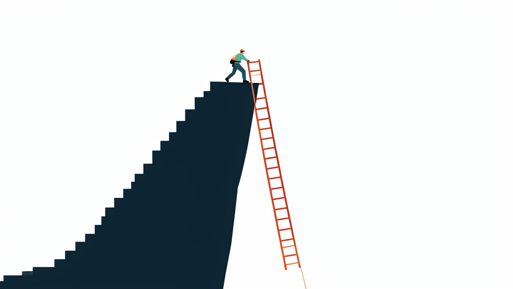

Illustration generated by AI (FLUX.2)

## How many layers were once thought to be enough?

Until roughly 2006, networks used in practice were mostly **shallow**: at most three layers, that is, at most **two hidden** ones. The classical argument is about the **shape of the decision regions** a network can form (Lippmann, *IEEE ASSP Magazine*, 1987):

[figure not shown]

The two right columns are **really trained** classifiers, not drawings — see [the figure generator](https://github.com/tomasvicar/MLR-public/blob/master/lectures/L8/code/make_figures.py).

## What one hidden layer can and cannot do

Universal approximation

One hidden layer with enough neurons approximates any continuous function on a compact domain (Cybenko 1989, Hornik 1991).

The catch: *enough*

- the neuron count can grow **exponentially** with the input dimension $d$,
- for some functions a **deep** network needs exponentially fewer neurons (Telgarsky 2016).

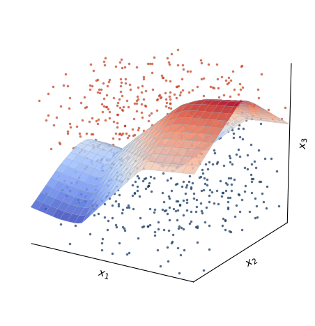

The level set $\hat p(\mathbf x) = 0.5$ of a network with one hidden layer — the hyperplanes bent into a smooth surface.

## Why depth pays off in practice

Deeper architectures bring a **higher level of abstraction**: low-level features formed in the first layers are combined into high-level features in the deeper ones. In practice this beats a shallow network of the same size.

[figure not shown]

The same idea will come back twice today: the first convolutional layer detects edges, the next one corners and textures, the deepest one object parts.

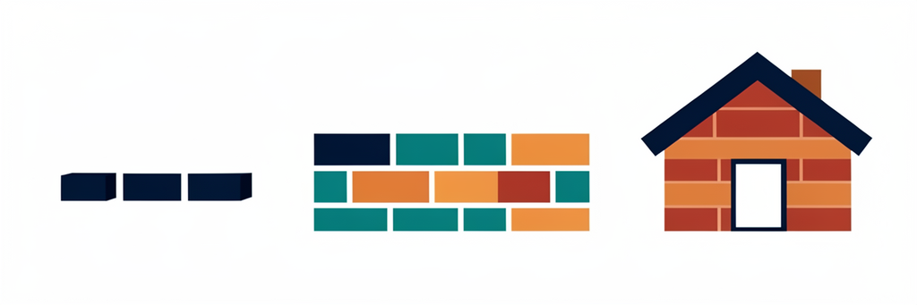

Illustration generated by AI (FLUX.2)

## The price of depth

✗ Huge increase in parameters

More data, memory and computation; **overfitting**.

✗ Vanishing signal

$\sigma'(z) \le \tfrac14$ per sigmoid layer: ten layers ≈ $4^{-10} \approx 10^{-6}$.

Remedies

**ReLU**, **batch normalization**, **weight initialization** (left plot); fewer parameters: the next block.

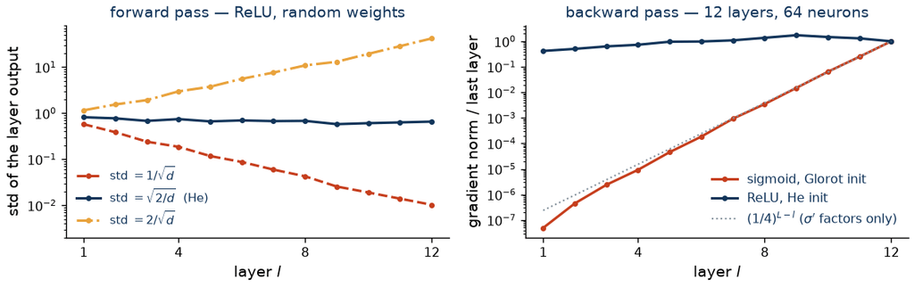

## 2 · From ANN to CNN

> Fifty neurons over a 200 × 200 colour image need six million weights. Fifty 3 × 3 convolutional filters need 1 350.

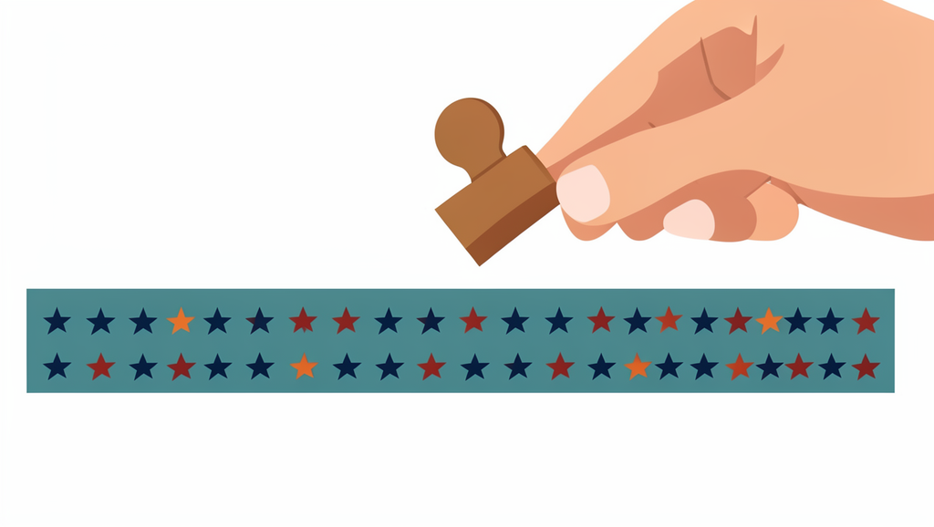

Illustration generated by AI (FLUX.2)

## ANN — fully connected

- Each neuron is connected to **each** neuron of the previous layer.
- Each weight of each neuron is **independent** of all the others.
- No notion of **neighbourhood**: shuffling the pixels changes nothing.
- One neuron has $d$ weights, one per input; for a colour image $200 \times 200 \times 3$:

  $$d = 120\,000$$
- A layer of $m$ neurons:

  $$d \cdot m = 120\,000 \cdot 50 = 6 \cdot 10^{6}$$

[figure not shown]

## CNN — local connections and shared weights

- **Local** connections: each neuron sees a small neighbourhood.
- **Shared** weights: the same feature is detected everywhere.
- One neuron — a $3 \times 3$ window over 3 channels:

  $$d = 3 \cdot 3 \cdot 3 = 27$$
- A layer of $K$ filters (here $K = 2$):

  $$d \cdot K = 27 \cdot 2 = 54$$

[figure not shown]

## Shared weights — shift the input, the map shifts

**Translation equivariance:** the same weights are applied at every position, so a shifted input gives the same activation map, shifted the same way — the layer learns a feature once and finds it everywhere.

[figure not shown]

## Counting the weights

Weights for a $200 \times 200 \times 3$ input and $3 \times 3$ filters

|  | fully connected | convolutional |
| --- | --- | --- |
| one neuron / filter | $120\,000$ | $27$ |
| two of them | $240\,000$ | $54$ |
| fifty of them | $6\,000\,000$ | $1\,350$ |

[figure not shown]

**More than 1 000×** fewer weights — $6\,000\,000$ vs $1\,350$, roughly $4\,400$× — and **independent of the image size**.

## 3 · Basic building blocks

> Six layer types — the core of every convolutional network; the next lecture adds the special blocks.

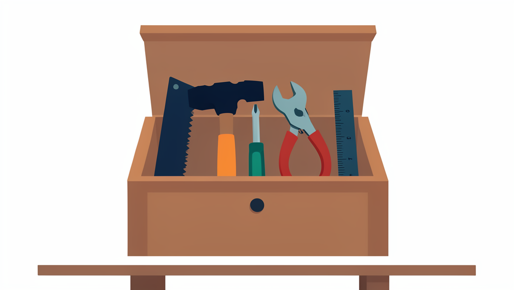

Illustration generated by AI (FLUX.2)

## Convolutional layer — the input

Input image $\mathbf x$ of size $W_x \times H_x \times D_x$ — **width**, **height** and **depth**.

- $W_x \times H_x$ is the spatial size of the image,
- $D_x$ is the number of **channels**: 1 for greyscale, 3 for RGB, more for a multimodal or multispectral image.

[figure not shown]

## Convolutional layer — the filter

Filter $\mathbf w$ of size $W_w \times H_w \times D_w$, usually square, $W_w = H_w = F$.

- $F$ is the size of the **local connection** — how big a neighbourhood one neuron sees,
- the depth equals the depth of the input, $D_w = D_x$: the filter **always** spans all channels.

[figure not shown]

## Convolutional layer — one output value

The **dot product** of the filter with the part of the input under it — for filter $k$ and the window centred at $(i,j)$:

$$z_k(i,j) = \sum_{u}\sum_{v}\sum_{d=1}^{D_x}
x(i+u,\, j+v,\, d)\; w_k(u,v,d) \;+\; b_k$$

with the offsets $u, v = -\tfrac{F-1}{2} \dots \tfrac{F-1}{2}$.

Looks familiar? Products and a sum — exactly the **inner potential** $z$ of a neuron:

$$z_k(i,j) = \mathbf w_k^\top \mathbf x_{ij} + b_k$$

$\mathbf x_{ij}$ — the $F \cdot F \cdot D_x$ input values under the window, unrolled into a vector.

[figure not shown]

## Convolution, worked out

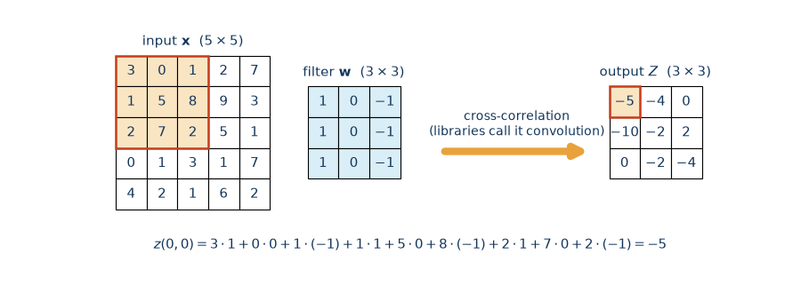

A vertical edge detector

Each output is the *left column minus the right column* of the window — for the first window $(3+1+2) - (1+8+2) = -5$. The output is $3 \times 3$, exactly $W_x - F + 1$ in each direction.

A **cross-correlation**, as in the formula on the previous slide and in every library (`Conv2d`): the filter is not flipped.

[code example — convolution and pooling from scratch, checked against SciPy](https://github.com/tomasvicar/MLR-public/blob/master/lectures/L8/code/convolution_from_scratch.py)

## Convolutional layer — the activation map

Sliding the filter over the whole image gives a smaller **activation map** $Z_k$ (also called a *feature map*):

$$W_Z = W_x - W_w + 1, \qquad
H_Z = H_x - H_w + 1, \qquad
D_Z = 1$$

[figure not shown]

For a $32 \times 32$ image and a $5 \times 5$ filter the map is $28 \times 28$ — one filter, one map, whatever the depth of the input was.

## Convolutional layer — K filters, one 3D map

Repeat the convolution with $K$ filters — this gives $K$ activation maps $Z_1 \dots Z_K$, which are **stacked** into one 3D activation map $A_l$:

[figure not shown]

- the output of a convolutional layer is a new 3D map with $D_A = K$,
- it is the **input of the next layer** — which is why the filters of the next layer have depth $K$.

Notation used from here on: $z_k(i,j)$ is one number, $Z_k$ one 2D map and $A_l$ the whole 3D stack of layer $l$.

## Hyperparameters of a convolutional layer

- number of filters in the layer $K$,
- their spatial extent $F$ (usually an odd number),
- the **stride** $S$ — the step of the sliding window,
- the amount of **zero padding** $P$ — how many rings of zeros are added at the border.

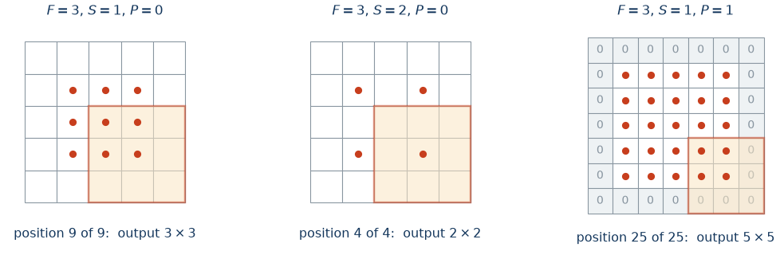

Stride $S > 1$ **shrinks** the map, padding $P > 0$ **grows** it back. With $F = 3$, $S = 1$ and $P = 1$ the spatial size is preserved exactly — the most common setting in practice.

## Output size of a convolutional layer

The input of layer $l$ (so far $W_x \times H_x \times D_x$), $W_l \times H_l \times D_l$, becomes the output $W_{l+1} \times H_{l+1} \times D_{l+1}$:

$$W_{l+1} = \frac{W_l - F_l + 2 P_l}{S_l} + 1, \qquad
H_{l+1} = \frac{H_l - F_l + 2 P_l}{S_l} + 1, \qquad
D_{l+1} = K_l$$

| input | $F$ | $S$ | $P$ | $K$ | output |
| --- | --- | --- | --- | --- | --- |
| $32 \times 32 \times 3$ | 3 | 1 | 1 | 16 | $32 \times 32 \times 16$ |
| $32 \times 32 \times 16$ | 3 | 1 | 0 | 32 | $30 \times 30 \times 32$ |
| $32 \times 32 \times 3$ | 5 | 3 | 0 | 8 | $10 \times 10 \times 8$ |
| $64 \times 64 \times 3$ | 5 | 2 | 2 | 8 | $32.5 \times 32.5$ — **does not fit** |

Rules

- all filters in one layer must have the **same** size,
- the output size should be an **integer** in every dimension — in the last row the windows do not tile the input; PyTorch silently drops the remainder (rounds down), so check it by hand.

## Playground: slide the filter yourself

[interactive chart not shown]

**Click** an output cell to see its dot product, an input or filter cell to change it (+1; shift-click −1).

filter:

stride **S** =

padding **P** =

## Convolutional layer — number of parameters

Input

3D map $W_l \times H_l \times D_l$

Output

3D map $W_{l+1} \times H_{l+1} \times K_l$

Hyperparameters

$K$, $F$, $S$, $P$

Learned parameters

**weights and biases** (below)

$$\underbrace{F_l \cdot F_l \cdot D_l \cdot K_l}_{\text{weights}}
\;+\; \underbrace{K_l}_{\text{biases}}$$

| input | $F$ | $K$ | weights | biases | total |
| --- | --- | --- | --- | --- | --- |
| $32 \times 32 \times 3$ | 3 | 16 | $432$ | $16$ | $448$ |
| $32 \times 32 \times 16$ | 3 | 16 | $2\,304$ | $16$ | $2\,320$ |
| $16 \times 16 \times 16$ | 3 | 32 | $4\,608$ | $32$ | $4\,640$ |
| $16 \times 16 \times 32$ | 5 | 32 | $25\,600$ | $32$ | $25\,632$ |

The number of parameters does **not** depend on $W_l$ or $H_l$: one convolutional layer has as many parameters for a thumbnail as for a 4K image.

[code example — output sizes and parameter counts of a whole architecture](https://github.com/tomasvicar/MLR-public/blob/master/lectures/L8/code/layer_sizes.py)

## Activation layer

Input

3D activation map $A_l$

Output

3D activation map $f(A_l)$ of the **same size**

Hyperparameters

**none**

Learned parameters

**none**

- Same as in a standard neural network — an **element-wise** application of the activation function, usually **ReLU**.
- The output layer uses **softmax**, which normalizes across the classes — not element-wise.

[figure not shown]

## ReLU and softmax

ReLU

$$f(z) = \max(0, z)$$

Cheap, does not saturate for $z > 0$, and its derivative is $0$ or $1$ — which is why gradients survive many layers.

Softmax

$$f(z_c) = \frac{e^{z_c}}{\sum_{j=1}^{C} e^{z_j}}, \quad c = 1 \dots C$$

Turns the logits of the $C$ classes into probabilities that sum to one; in a CNN classifier it sits in the output layer, together with the cross-entropy loss.

[figure not shown]

## Pooling layer

Input

an image or an activation map

Output

**shrunk in width and height**; the depth unchanged

Hyperparameters

**max** (more often) or **average**; window $F$, stride $S$

Learned parameters

**none**

- Applied to each **channel separately**; it cuts the **computation** in the deeper layers and the **parameters** of the fully connected (FC) layer.

Max pooling passes on the **strongest** activation in the window: *was the feature there at all?* rather than *exactly where?*

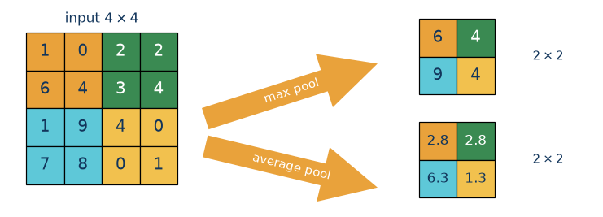

## Pooling — hyperparameters and output size

Hyperparameters: the spatial extent $F$ (usually 2 or 3) and the stride $S$ (usually 2). Usually **no padding**; **no learned parameters**.

$$W_{l+1} = \frac{W_l - F_l}{S_l} + 1, \qquad
H_{l+1} = \frac{H_l - F_l}{S_l} + 1, \qquad
D_{l+1} = D_l$$

[figure not shown]

- $F = S$ gives **non-overlapping** windows, the usual choice,
- $F > S$ gives overlapping windows,
- $32 \times 32 \times 16$ with $F = S = 2$ becomes $16 \times 16 \times 16$: a quarter of the values, the same depth,
- the output size should again be an **integer**.

## Pooling or a strided convolution?

Both halve the map; the difference is **what is kept** and **who decides**.

[figure not shown]

Modern networks often downsample with a **strided convolution** — learned, but with parameters; the next lecture builds on it (down- and up-sampling).

## Fully connected layer

Input

a map, **vectorized** — the spatial structure is lost

Output

a vector (or a scalar)

Hyperparameters

the number of neurons $K_l$

Learned parameters

weights and biases (next slide)

- The **same layer** as in an ordinary neural network.
- ReLU, or softmax in the output layer.
- Turns *features* into *a decision*.

[figure not shown]

## Fully connected layer — parameters

- Hyperparameter: the number of neurons in the layer $K_l$.
- Input size (vectorized) $W_l H_l D_l$ becomes output size $K_l$.
- Between two consecutive FC layers: $K_{l-1}$ becomes $K_l$.
- Number of parameters:

  $$W_l H_l D_l K_l + K_l$$

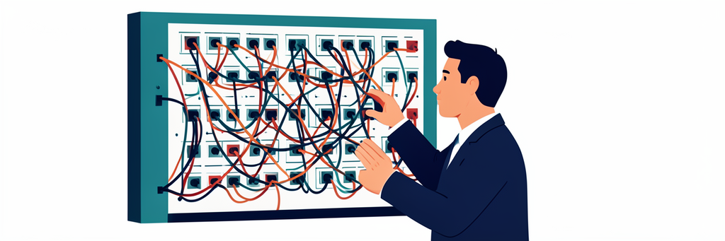

Illustration generated by AI (FLUX.2)

| input | $K$ | parameters |
| --- | --- | --- |
| $8 \times 8 \times 32 = 2\,048$ | 64 | $2\,048 \cdot 64 + 64 = 131\,136$ |
| $64$ | 10 | $64 \cdot 10 + 10 = 650$ |
| $16 \times 16 \times 32 = 8\,192$ | 64 | $524\,352$ |

One FC layer can easily cost more than all convolutional layers combined — that is why pooling shrinks the map before it.

## Dropout layer

Input

outputs of a convolutional or FC layer

Output

size $W_l \times H_l \times D_l$ **unchanged**

Hyperparameters

$p$ — the probability that a neuron is **kept**

Learned parameters

**none**

- **Randomly disables** some neuron outputs; **training phase only** — in prediction the whole network is active.
- Placed **between** layers: after the activation, before the next conv or FC.

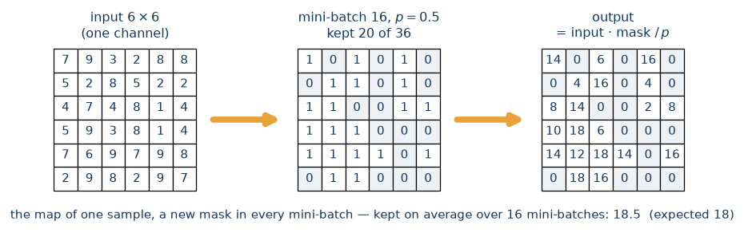

Careful: PyTorch’s `nn.Dropout(p)` uses $p$ for the opposite — the probability that a neuron **is** dropped.

## Batch normalization layer

Input

the output of a conv or FC layer

Output

size $W_l \times H_l \times D_l$ **unchanged**

Hyperparameters

the decay $\rho$ of the running mean and variance used in prediction

Learned parameters

**two per channel**: the scale $\gamma_j$ and the shift $\beta_j$

- Normalizes to **zero mean and unit variance**, **per channel** $j$: the statistics $\mu_{B_j}$, $\sigma^2_{B_j}$ run over the batch **and** all positions.
- Placed **between** the convolution and its activation function.

[figure not shown]

## The same layers in PyTorch

```python
import torch.nn as nn

nn.Conv2d(3, 16, kernel_size=3, padding=1)  # D=3 → K=16, F=3, P=1: 3·3·3·16 + 16 = 448
nn.ReLU()                                   # no parameters
nn.MaxPool2d(2)                             # F = S = 2, no parameters
nn.BatchNorm2d(16)                          # γ_j, β_j for 16 channels: 32 parameters
nn.Dropout(p=0.5)                           # p = probability of DROPPING (slides: keeping)
nn.Linear(8 * 8 * 32, 64)                   # 2048 · 64 + 64 = 131 136
```

| slides | $D$ | $K$ | $F$ | $S$ | $P$ |
| --- | --- | --- | --- | --- | --- |
| `nn.Conv2d` | `in_channels` | `out_channels` | `kernel_size` | `stride` | `padding` |

The network of the table on the next slides, written this way, has exactly $148\,442$ parameters.

## 4 · Basic CNN architecture

> Convolution, activation, pooling, repeat — and a fully connected layer at the very end.

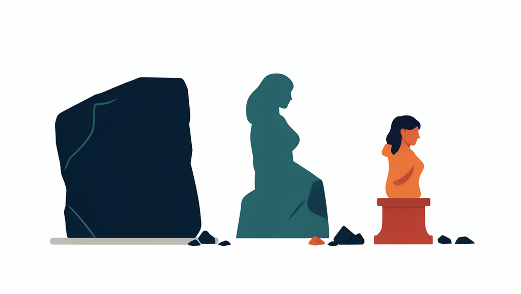

Illustration generated by AI (FLUX.2)

## A typical convolutional network

- (**conv + ReLU**) × 2–3 → **max pooling**, the block repeated a few times.
- Then **1–3 FC layers**: ReLU in all but the last, **softmax** at the output.

[figure not shown]

Width and height **shrink**, depth **grows**; at the end a 1D feature vector is classified by the output FC layer.

## Sizes and parameters, layer by layer

| layer | output | parameters |
| --- | --- | --- |
| input | $32 \times 32 \times 3$ | $0$ |
| conv $3\times3$, $K{=}16$, $P{=}1$ | $32 \times 32 \times 16$ | $448$ |
| conv $3\times3$, $K{=}16$, $P{=}1$ | $32 \times 32 \times 16$ | $2\,320$ |
| max pool $2\times2$, $S{=}2$ | $16 \times 16 \times 16$ | $0$ |
| conv $3\times3$, $K{=}32$, $P{=}1$ | $16 \times 16 \times 32$ | $4\,640$ |
| conv $3\times3$, $K{=}32$, $P{=}1$ | $16 \times 16 \times 32$ | $9\,248$ |
| max pool $2\times2$, $S{=}2$ | $8 \times 8 \times 32$ | $0$ |
| FC, $K{=}64$ | $64$ | $131\,136$ |
| FC, $K{=}10$ | $10$ | $650$ |
| **total** |  | $\mathbf{148\,442}$ |

[figure not shown]

The four convolutional layers hold $16\,656$ parameters, the first FC layer alone $131\,136$ — **88 %** of the network.

[code example — the same table computed from the layer formulas](https://github.com/tomasvicar/MLR-public/blob/master/lectures/L8/code/layer_sizes.py)

## Playground: size a network yourself

All convolutions are 3×3 with *S* = 1, *P* = 1; pooling is 2×2 with *S* = 2.

input side **W** =

filters in block 1, **K₁** =

filters in block 2, **K₂** =

neurons of the first FC layer =

pooling after block 1  
pooling after block 2  
global average pooling before the FC layers

## Receptive field — what the layers see

The receptive field of one neuron **grows with depth**, so deeper layers can describe larger and more abstract structures: edges, then corners and textures, then object parts.

[figure not shown]

For the stack conv $5\times5$ → pool $2\times2$ → conv $3\times3$ → pool $2\times2$ → conv $3\times3$ the receptive field grows to 5 → 10 → 20 pixels after the three convolutions.

Layout after Zeiler & Fergus, *Visualizing and Understanding Convolutional Networks*, ECCV 2014 (arXiv:1311.2901).

## Playground: how far does one neuron see?

[interactive chart not shown]

add a layer:

presets:

## Filters and activation maps

[figure not shown]

**One filter ⇒ one activation map.** Trained only to classify the stroke orientation, the layer learned **oriented colour-edge detectors** by itself.

[code example — this convolutional layer trained from scratch in NumPy](https://github.com/tomasvicar/MLR-public/blob/master/lectures/L8/code/cnn_filters.py)

## Where the filters come from

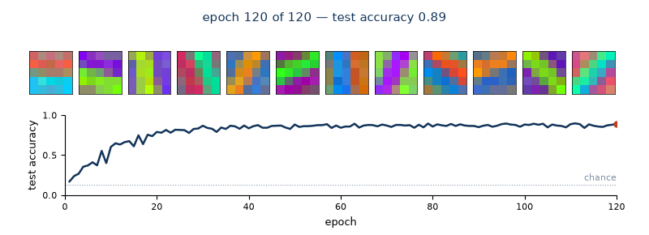

From **random initialization** to the end of training: the gradient of the cross-entropy loss and an L2 penalty on the weights turn noise into edge detectors; test accuracy from **near chance (1/8)** to **0.89**.

## 5 · Recap

> Three sets of questions: from depth, through the building blocks, to a whole network.

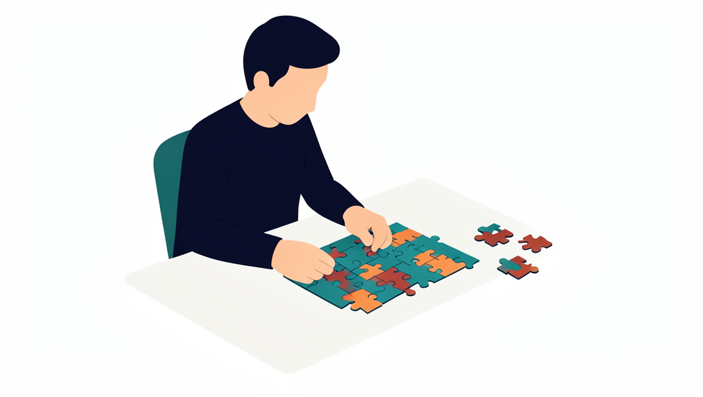

Illustration generated by AI (FLUX.2)

## Summary

Depth

**Depth** buys abstraction: low-level features are combined into high-level ones. It costs parameters and brings vanishing activations and gradients.

Convolution

- A neuron with a *local* input and *shared* weights — equivariant to translation. Its number of parameters, $F F D K + K$, does not depend on the image size.
- One filter gives one 2D activation map; $K$ filters give a 3D map of depth $K$, which is the input of the next layer.

Sizes

Output sizes — and the result should be an integer:

$$\begin{aligned}
\text{convolution: }& \frac{W - F + 2P}{S} + 1 \\
\text{pooling: }& \frac{W - F}{S} + 1
\end{aligned}$$

Other layers and the whole network

- **Pooling** shrinks width and height, keeps the depth and has no parameters.
- **ReLU** in the hidden layers, **softmax** in the output layer; **dropout** as in an ordinary network, **batch normalization** per channel, over the batch and all positions.
- A typical CNN: (conv + ReLU) × n → pooling, the block repeated a few times, then 1–3 fully connected layers — width and height shrink, depth grows.

## Recap quiz I — depth and the move to convolutions

Shallow versus deep

- What limits the shape of the **decision regions** of a network with no, one and two hidden layers? What does the universal approximation theorem add — and what does it *not* promise?
- Name the two **drawbacks of depth** and one remedy for each.

From ANN to CNN

- Why is a fully connected layer a bad idea for an image? Give the **numerical** argument and the **structural** one.
- What exactly do **shared weights** mean, and what property of the layer do they give us?
- A $200 \times 200 \times 3$ image, filters $3 \times 3$, $K = 50$: how many weights does the convolutional layer have, and how many would a fully connected layer of 50 neurons have?

## Recap quiz II — the building blocks

Convolution and sizes

- Write the formula for **one output value** of a convolutional layer. Over how many indices does the sum run and why?
- Why is a convolution *the same thing* as the inner potential of a neuron? How many biases does one filter have, and why only one?
- Input $64 \times 64 \times 8$, $F = 3$, $S = 1$, $P = 1$, $K = 24$: give the **output size** and the **number of parameters**.
- The same input with $S = 2$ and $P = 0$: what happens, and why is it a problem?

Pooling, dropout, batch normalization

- What does **max pooling** throw away, and why is that useful? How many parameters does it have?
- Which layers change the **depth** of the map, and which do not?
- Where would you put **batch normalization** and where **dropout**, and how does each of them behave differently in training and in prediction?

## Recap quiz III — the whole network

Architecture and parameters

- Describe the **typical order** of layers in a CNN. Why does the width shrink while the depth grows?
- In the architecture from the table, which layer holds most of the parameters? What would you change to make it cheaper?

Receptive field and filters

- Two $3 \times 3$ convolutions in a row versus one $5 \times 5$: compare the **receptive field** and the **number of parameters**.
- How large is the receptive field of a neuron after conv $5\times5$ → pool $2\times2$ → conv $3\times3$?
- Why do the first-layer filters end up looking like **oriented edge detectors**, even though nobody designed them that way?